# R Notebook

```r
fatalities <- read.csv("Fatalities.csv")
library(tidyverse)
```

Create a visualization that tracks the number of alcohol related vehicle fatalities (afatal) for AL, AZ, AR, CA, and CO over time. Note, your software may have read the variable year in as a factor, be sure to change it to numeric before plotting the data.

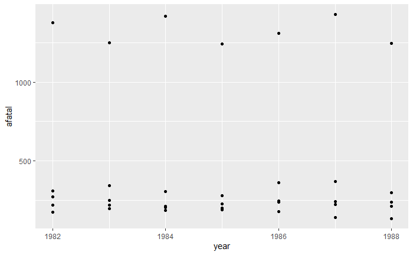

```r
fatalities %>%
  filter(state %in% c("al", "az", "ar", "ca", "co")) %>%
  ggplot(aes(x = year, y = afatal)) + geom_point()
```

Create a new variable, Population in 100,000s based on the existing variable pop. Run a standard OLS model (that includes all states) predicting alcohol fatalities (afatal) by beer tax (beertax) and your new population variable (population in 100,000s). Interpret the coefficients on population and beertax. Note, beertax has the opposite effect of the intended policy (higher beertaxes should reduce consumption and reduce the number of alcohol related fatalities). Why might we be finding these counterintuitive effects?

```r
fatalities$pop_100k <- fatalities$pop/100000
fatal_lm <- lm(afatal ~ beertax + pop_100k, data = fatalities)
summary(fatal_lm)
```

```
Call:
lm(formula = afatal ~ beertax + pop_100k, data = fatalities)

Residuals:
    Min      1Q  Median      3Q     Max
-507.77  -55.55   -0.27   38.51 1267.89

Coefficients:
            Estimate Std. Error t value Pr(>|t|)
(Intercept) -15.1023    15.0040  -1.007    0.315
beertax     102.5215    17.3596   5.906 8.66e-09 ***
pop_100k      5.1887     0.1635  31.736  < 2e-16 ***
---
Signif. codes:  0 ‘***’ 0.001 ‘**’ 0.01 ‘*’ 0.05 ‘.’ 0.1 ‘ ’ 1

Residual standard error: 151.2 on 333 degrees of freedom
Multiple R-squared:  0.7533,    Adjusted R-squared:  0.7518
F-statistic: 508.4 on 2 and 333 DF,  p-value: < 2.2e-16
```

```r
library(plm)
fatal2 <- pdata.frame(fatalities, index = c("state","year"))
fatal_plm <- plm(afatal ~ beertax + pop_100k, data = fatal2, model = "within")
summary(fatal_plm)
```

```
Oneway (individual) effect Within Model

Call:
plm(formula = afatal ~ beertax + pop_100k, data = fatal2, model = "within")

Balanced Panel: n = 48, T = 7, N = 336

Residuals:
     Min.   1st Qu.    Median   3rd Qu.      Max.
-439.7566  -14.9218   -1.0461   16.5591  478.5185

Coefficients:
          Estimate Std. Error t-value  Pr(>|t|)
beertax  -101.4076    70.5547 -1.4373    0.1517
pop_100k  -10.0280     1.7735 -5.6543 3.789e-08 ***
---
Signif. codes:  0 ‘***’ 0.001 ‘**’ 0.01 ‘*’ 0.05 ‘.’ 0.1 ‘ ’ 1

Total Sum of Squares:    1571900
Residual Sum of Squares: 1412800
R-Squared:      0.10122
Adj. R-Squared: -0.052763
F-statistic: 16.1051 on 2 and 286 DF, p-value: 2.3563e-07
```

Does the model in question 9 control for differences in total land area for each state? Why or why not?

State could serve as a proxy for total land area, but then states with similar land area could over-account for the effect of land area for a particular size. But either way not variable for land was included so the model does not specifically adjust for it.

Re-estimate the model from question 9, but now include unemployment (unemp). What is the effect of unemployment on alcohol fatalities?

```r
fatal_plm2 <- plm(afatal ~ beertax + pop_100k + unemp, data = fatal2, model = "within")
summary(fatal_plm2)
```

```
Oneway (individual) effect Within Model

Call:
plm(formula = afatal ~ beertax + pop_100k + unemp, data = fatal2,
    model = "within")

Balanced Panel: n = 48, T = 7, N = 336

Residuals:
     Min.   1st Qu.    Median   3rd Qu.      Max.
-432.3121  -16.6078   -1.9936   16.4423  469.1254

Coefficients:
         Estimate Std. Error t-value  Pr(>|t|)
beertax  -76.0389    72.4291 -1.0498    0.2947
pop_100k -10.8199     1.8476 -5.8561 1.304e-08 ***
unemp     -3.7959     2.5447 -1.4917    0.1369
---
Signif. codes:  0 ‘***’ 0.001 ‘**’ 0.01 ‘*’ 0.05 ‘.’ 0.1 ‘ ’ 1

Total Sum of Squares:    1571900
Residual Sum of Squares: 1401800
R-Squared:      0.10819
Adj. R-Squared: -0.048273
F-statistic: 11.5244 on 3 and 285 DF, p-value: 3.7469e-07
```

Look at your results from question 11 above. Does the model imply that the effects of a one-unit change in beertax results in the same impact on fatalities for all states in the model? If so why, and why is this potentially a problem? How might you improve the model?